# Coursera MAchine Learning

Gregory Caiola

January 29, 2016

EXECUTIVE SUMMARY

## Question 3

- First we load the data and explore its structure.

```r
names(train)
```

```
  [1] "X"                        "user_name"
  [3] "raw_timestamp_part_1"     "raw_timestamp_part_2"
  [5] "cvtd_timestamp"           "new_window"
  [7] "num_window"               "roll_belt"
  [9] "pitch_belt"               "yaw_belt"
 [11] "total_accel_belt"         "kurtosis_roll_belt"
 [13] "kurtosis_picth_belt"      "kurtosis_yaw_belt"
 [15] "skewness_roll_belt"       "skewness_roll_belt.1"
 [17] "skewness_yaw_belt"        "max_roll_belt"
 [19] "max_picth_belt"           "max_yaw_belt"
 [21] "min_roll_belt"            "min_pitch_belt"
 [23] "min_yaw_belt"             "amplitude_roll_belt"
 [25] "amplitude_pitch_belt"     "amplitude_yaw_belt"
 [27] "var_total_accel_belt"     "avg_roll_belt"
 [29] "stddev_roll_belt"         "var_roll_belt"
```

[output cut: 65 more lines]

```r
str(train)
```

```
'data.frame':   19622 obs. of  160 variables:
 $ X                       : int  1 2 3 4 5 6 7 8 9 10 ...
 $ user_name               : Factor w/ 6 levels "adelmo","carlitos",..: 2 2 2 2 2 2 2 2 2 2 ...
 $ raw_timestamp_part_1    : int  1323084231 1323084231 1323084231 1323084232 1323084232 1323084232 1323084232 1323084232 1323084232 1323084232 ...
 $ raw_timestamp_part_2    : int  788290 808298 820366 120339 196328 304277 368296 440390 484323 484434 ...
 $ cvtd_timestamp          : Factor w/ 20 levels "02/12/2011 13:32",..: 9 9 9 9 9 9 9 9 9 9 ...
 $ new_window              : Factor w/ 2 levels "no","yes": 1 1 1 1 1 1 1 1 1 1 ...
 $ num_window              : int  11 11 11 12 12 12 12 12 12 12 ...
 $ roll_belt               : num  1.41 1.41 1.42 1.48 1.48 1.45 1.42 1.42 1.43 1.45 ...
 $ pitch_belt              : num  8.07 8.07 8.07 8.05 8.07 8.06 8.09 8.13 8.16 8.17 ...
 $ yaw_belt                : num  -94.4 -94.4 -94.4 -94.4 -94.4 -94.4 -94.4 -94.4 -94.4 -94.4 ...
 $ total_accel_belt        : int  3 3 3 3 3 3 3 3 3 3 ...
 $ kurtosis_roll_belt      : Factor w/ 397 levels "","-0.016850",..: 1 1 1 1 1 1 1 1 1 1 ...
 $ kurtosis_picth_belt     : Factor w/ 317 levels "","-0.021887",..: 1 1 1 1 1 1 1 1 1 1 ...
 $ kurtosis_yaw_belt       : Factor w/ 2 levels "","#DIV/0!": 1 1 1 1 1 1 1 1 1 1 ...
```

[output cut: 86 more lines]

```r
table(train$classe)
```

```
   A    B    C    D    E
5580 3797 3422 3216 3607
```

```r
modelset <- train[,c(1:11, 37:49 ,60:68, 84:86, 160) ]
modelset1 <- na.omit(modelset)
testset1<-test[,c(1:11, 37:49 ,60:68, 84:86, 160) ]
```

There seem to be a substantial amount of variables that our empty. We drop these to create our modelling dataset.

Our outcome variable class has 5 outcomes and seems fairly evenly distributed. It is also populated for all observations. This should allow for reasonable predictions.

```r
library(randomForest)
rf1<-randomForest(modelset$classe ~ ., data=modelset,importance=T)

rf1$confusion
```

```
     A    B    C    D    E class.error
A 5580    0    0    0    0           0
B    0 3797    0    0    0           0
C    0    0 3422    0    0           0
D    0    0    0 3216    0           0
E    0    0    0    0 3607           0
```

```r
#table(modelset1$num_window, modelset1$classe)
```

We choose to build a random forest because it should be a good unbiased predictor. We do not have to specify cross validation here because our predictions are based on the out of bag trees. This is essentially “n-fold” cross validation

However in our first model, we see perfect predcions. A bit of analysis shows a few variables (num_window and the datestamps) are direct predictors. We can remove these and run a new forest

```r
modelset2 <- modelset[,c(2, 8:37)]
rf2 <- randomForest(modelset2$classe ~ ., data=modelset2,importance=T)
rf2$confusion
```

```
     A    B    C    D    E class.error
A 5525   15   13   21    6 0.009856631
B   29 3749   15    4    0 0.012641559
C    5   25 3378   14    0 0.012857978
D    6    0   38 3169    3 0.014614428
E    3    6    7    6 3585 0.006099251
```

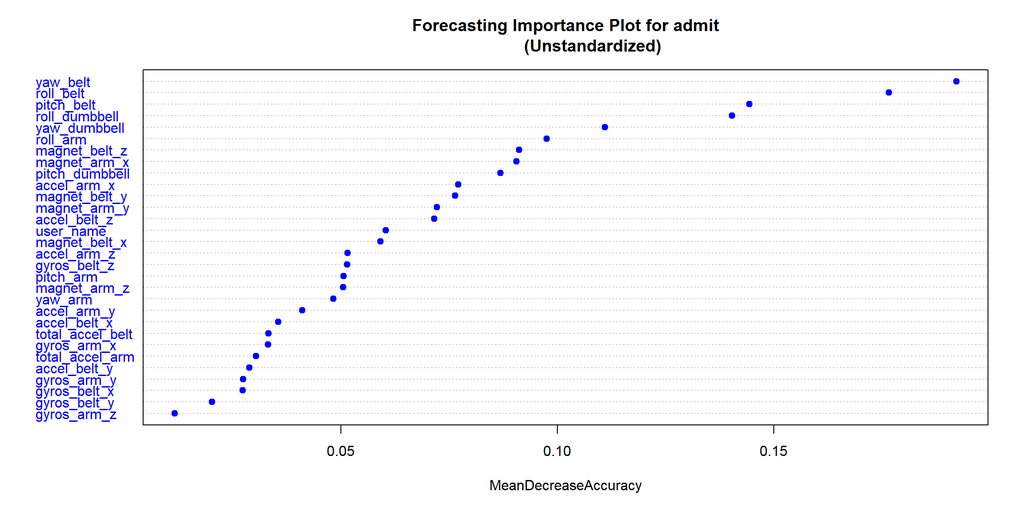

```r
par(mfrow=c(1,1))
varImpPlot(rf2,type=1,scale=F,
           main="Forecasting Importance Plot for admit
           (Unstandardized)",col="blue",cex=1,pch=19)
```

```r
#predict(rf1, testset1, type="response")
```

With the new parameters we see a very strong 99% prediction. We can built a variable importance plot and see a range of important predictors, starting with yaw_belt